# Case 1 - Who’s #1: INSEAD, Harvard, Wharton, LBS?

Dai Yao (dai.yao@nus.edu.sg)

28/03/2019

**NOTE: You should never share this document with a person who is not taking the course now, or a person who will take the course later. Neither should you post the document online.**

Let’s first load the necessary packages and the business school survey data.

```r
rm(list=ls())

library(readxl)
library(dplyr)
```

```r
library(reshape2)
library(ggplot2)
# for perceptual map
library(FactoMineR)
library(factoextra)
# for visualizing the dendrogram
library(ggdendro)
# for discrimination analysis
library(MASS)
# for multinomial logit
library(mlogit)
# raw data
biz.school.data <- as.data.frame(
  read_xlsx("Whosn1 Data.xlsx", sheet="Data"))
```

## Question 1: snake chart

For illustration purpose, we only use the first few questions.

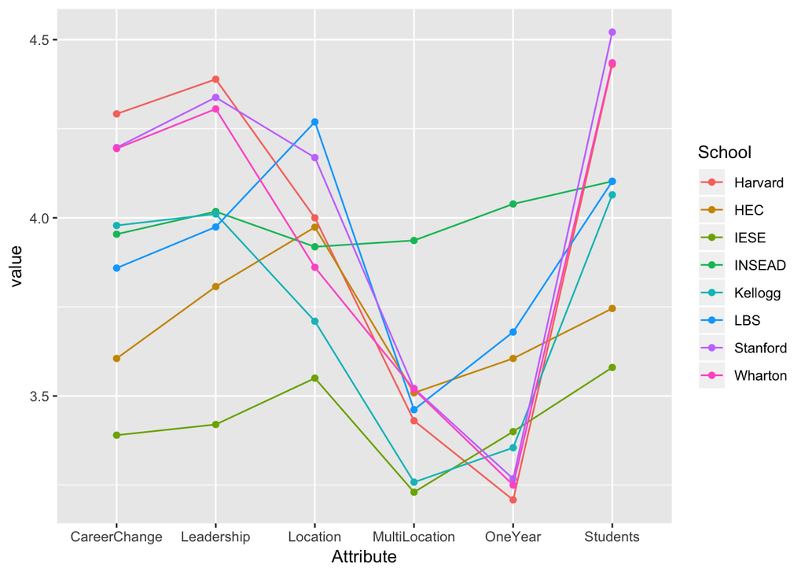

```r
# perception raw data
percep.raw.data <- biz.school.data[
  , c("SchoolRated", paste("Q17", seq(1, 30), sep="_"))]

# create the perception data for generating perceptual map
# NOTE: in the last step in the Pipe, you need to use dplyr::select to use the "select" function in dplyr. MASS also has this function, and masks the previous one since it's loaded later
percep.data <- percep.raw.data %>%
  group_by(SchoolRated) %>%
  mutate(mean1=mean(Q17_1), mean2=mean(Q17_2),
         mean4=mean(Q17_4),
         mean5=mean(Q17_5), mean6=mean(Q17_6),
         mean8=mean(Q17_8)) %>%
  slice(1) %>% dplyr::select(SchoolRated, starts_with("mean"))

# remove the first column
percep.data = percep.data[, c(-1)]
# to "melt" the data, we first transpose the data.frame
percep.data <- t(percep.data)

# specify the rownames and colnames
colnames(percep.data) <- c("Harvard", "HEC", "IESE", "INSEAD", "Kellogg", "LBS", "Stanford", "Wharton")
rownames(percep.data) <- c("OneYear", "Students",  "Leadership", "CareerChange", "Location", "MultiLocation")

percep.data <- as.data.frame(percep.data)
percep.data <- cbind(Attribute=rownames(percep.data), percep.data)
percep.data$Attribute = as.character(percep.data$Attribute)

percep.data.long <- melt(
  percep.data, id.vars="Attribute", variable.name="School", value.name="value")

ggplot(data=percep.data.long, aes(
  x=Attribute, y=value, group=School, color=School)) +
  geom_line() + geom_point()
```

**Note:** Creating the snake charts for students from different countries is simple once you can do it for all the students. Thus I omit the results. Same for generating the perceptual maps.

## Question 2: perceptual map

```r
# we only keep the perception data for different schools
percep.data = percep.data[, c(-1)]
# to run PCA, we need to have the schools as rows, and attributes as columns
percep.data <- t(percep.data)
bschool.pca <- PCA(percep.data, graph=FALSE)
```

By plotting the variances explained by each underlying dimensions, we know that for the perception data, 2 dimensions need to be retained (which explain more than 10% of variances in the data).

*Note: Other data may show different patterns.*

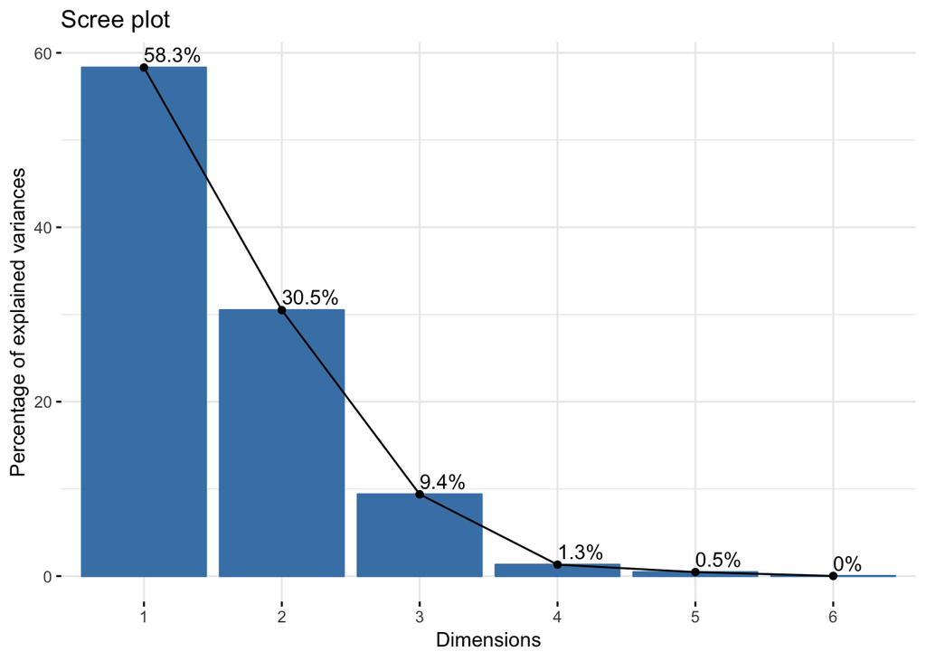

```r
fviz_screeplot(bschool.pca, addlabels = TRUE)
```

Now we can visualize the perceptual map for the various business schools, and the attributes.

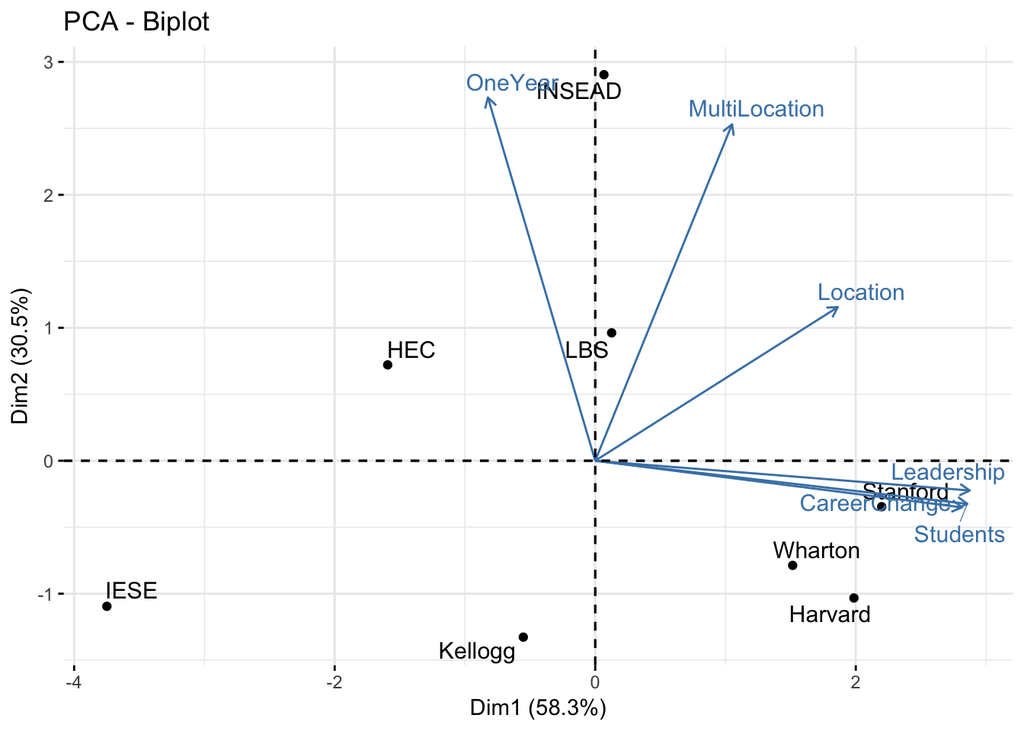

```r
fviz_pca_biplot(bschool.pca, axes=c(1, 2), repel=TRUE)
```

## Question 3: optimize the positioning of the INSEAD brand?

## Question 4: segmentation and discrimination analysis

### Q4.1: segmentation analysis

Let’s first prepare the segmentation and discrimination data.

```r
# segmentation data
seg.raw.data <- biz.school.data[, c(
  "ResponseID", paste("Q6", seq(1, 12), sep="_"),
  paste("Q7", seq(1, 10), sep="_"))]
# we should keep only the 1st record for each student
seg.data <- seg.raw.data %>% group_by(ResponseID) %>% slice(1)

# discrimination data
dis.raw.data <- biz.school.data[, c(
  "ResponseID", "Q1b", "Female", "Age", "Work_exp")]
dis.data <- dis.raw.data %>% group_by(ResponseID) %>% slice(1)
# change the column name "Q1b" to be "GMAT"
colnames(dis.data) <- c("ResponseID", "GMAT", "Female", "Age", "Work_exp")
```

Some students report -1 as GMAT score, we first set the value to be NA for these students.

```r
dis.data$GMAT[dis.data$GMAT==-1] = NA
```

Now let’s check the completeness of the data.

```r
table(complete.cases(seg.data))
```

```
##
## TRUE
##  460
```

```r
table(complete.cases(dis.data))
```

```
##
## FALSE  TRUE
##    80   380
```

The results suggest that for *dis.data*, there are 80 rows with incomplete data. We can either drop those rows, or fill up the missing values with the average. In this illustration, I will just drop those with missing values for simplicity.

```r
dis.data.new = dis.data[complete.cases(dis.data), ]
seg.data.new = seg.data[complete.cases(dis.data), ]
```

Now let’s calculate the distances between different students, perform the hierarchical clustering, and create the dendrogram plot.

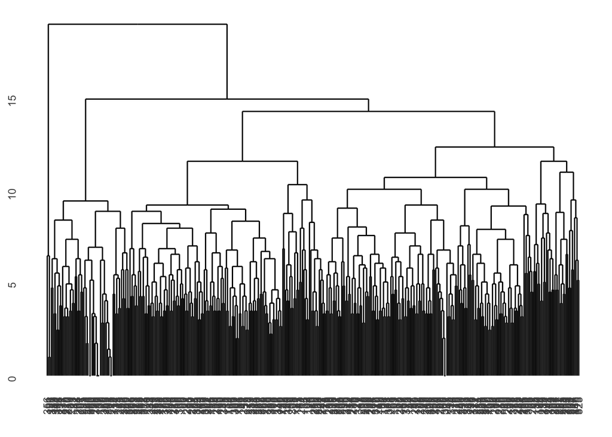

```r
# calculate distance matrix
dist.matrix = dist(seg.data.new[, c(-1)])
# perform the hirarchical clustering using complete join method
pw.cluster.complete = hclust(dist.matrix)
# create the dendrogram plot
ggdendrogram(pw.cluster.complete)
```

The dendrogram plot is complex because all the student ids are overlapping with each other. Nevertheless, we can tentatively cut the tree into three groups, and see if the groups are different (in at least some variables).

**Note:** You may decide to cut the tree into other number of groups based on your own criteria.

```r
groups = cutree(pw.cluster.complete, k=3)
# display the distribution of students across groups
table(groups)
```

```
## groups
##   1   2   3
## 321  56   3
```

We notice that there are only 3 students in the 3rd group, but let’s first calculate the average answers for each group.

```r
mean.answers1 = apply(seg.data.new[which(groups==1), c(-1)], 2, mean)
mean.answers2 = apply(seg.data.new[which(groups==2), c(-1)], 2, mean)
mean.answers3 = apply(seg.data.new[which(groups==3), c(-1)], 2, mean)
mean.answers = rbind(mean.answers1, mean.answers2, mean.answers3)
rownames(mean.answers) <- c("G1", "G2", "G3")
mean.answers
```

```
##        Q6_1     Q6_2     Q6_3     Q6_4     Q6_5     Q6_6     Q6_7     Q6_8
## G1 3.093458 4.557632 4.112150 4.233645 3.707165 3.507788 3.464174 3.271028
## G2 4.178571 4.464286 4.428571 4.446429 4.410714 4.482143 4.410714 3.785714
## G3 1.000000 1.333333 1.333333 1.333333 1.000000 1.000000 1.666667 1.000000
##        Q6_9    Q6_10    Q6_11    Q6_12     Q7_1     Q7_2     Q7_3     Q7_4
## G1 3.006231 3.956386 4.408100 2.489097 4.548287 1.395639 2.831776 2.526480
## G2 3.410714 4.446429 4.553571 3.357143 4.732143 3.410714 4.107143 3.214286
## G3 1.666667 1.000000 1.333333 1.666667 1.000000 1.333333 1.666667 1.666667
##        Q7_5     Q7_6     Q7_7     Q7_8     Q7_9    Q7_10
## G1 1.535826 1.800623 3.395639 3.953271 3.878505 3.797508
## G2 3.142857 3.821429 4.267857 4.321429 4.500000 4.553571
## G3 2.000000 1.666667 1.333333 1.333333 1.666667 1.000000
```

The groups look reasonable, because each group is quite different from the other groups in at least some variables. So we can cluster the students into three different groups. We now use KMeans to create a more balanced clustering result.

```r
cluster.partition = kmeans(seg.data.new[, c(-1)], 3)
# now the clustering result is more balanced
table(cluster.partition$cluster)
```

```
##
##   1   2   3
## 105 100 175
```

We can see the clustering results are much more balanced. You can further check if the three groups are still quite different from each other. For simplicity, I omit this comparison.

### Q4.2: discrimination analysis

To perform the discrimination analysis, we first combine the clustering results with demographic information of the students.

```r
dis.data.new$Group = as.factor(cluster.partition$cluster)
```

We use a linear discrimination analysis.

```r
seg.lda <- lda(Group ~ GMAT+Female+Age+Work_exp, data=dis.data.new)
seg.lda
```

```
## Call:
## lda(Group ~ GMAT + Female + Age + Work_exp, data = dis.data.new)
##
## Prior probabilities of groups:
##         1         2         3
## 0.2763158 0.2631579 0.4605263
##
## Group means:
##       GMAT    Female   Age Work_exp
## 1 647.6190 0.2952381 36.60 4.266667
## 2 612.5000 0.5200000 33.69 2.960000
## 3 623.1429 0.2914286 35.88 4.057143
##
## Coefficients of linear discriminants:
##                   LD1          LD2
## GMAT      0.004617814 -0.009510354
## Female   -0.674469432 -1.042104785
## Age       0.008861536 -0.301117117
## Work_exp  0.421748571  0.653600300
##
## Proportion of trace:
##    LD1    LD2
## 0.8669 0.1331
```

```r
seg.predict1 = predict(seg.lda)
table(
  dis.data.new$Group, seg.predict1$class,
  dnn=c('Actual','Predicted'))
```

```
##       Predicted
## Actual   1   2   3
##      1  12  14  79
##      2   2  36  62
##      3   9  26 140
```

The results are not very nice though, because the diagonal elements are not that large for some groups.

*Do you have any idea how to improve the accuracy of discrimination?*

It is important to have enough accuracy. The reason is because discrimination analysis, if done properly as we said in class, could enable us to identify the potential group membership of any new customer (here student), and to understand his or her preference better, which can be very useful for subsequent marketing initiatives.

Let’s try to improve the accuracy by looking at the details of the demographic variables. We first check the distribution of *GMAT, Age*, and *Work_exp*.

```r
# let's look at the distribution of GMAT,Age and Work_exp
table(dis.data.new$GMAT)
```

```
##
## 200 300 350 400 450 500 550 600 650 700 750
##   1   1   1   5  13  27  45  68  82 110  27
```

```r
table(dis.data.new$Age)
```

```
##
## 28 29 30 31 32 33 34 35 36 37 38 39 40 41 42 43 44 45 46 47 48 49 51
##  4  7 38 35 23 33 40 43 27 19 11 32 10 17 10  8  6  5  4  3  2  2  1
```

```r
table(dis.data.new$Work_exp)
```

```
##
##  1  2  3  4  5  6  7
## 55 43 60 97 39 52 34
```

We can see that there are only limited number of values in *Work_exp*. Let’s see what will happen if we treat each *Work_exp* value as having a different effect on discrimination.

```r
seg.lda <- lda(Group ~ GMAT+Female+Age+as.factor(Work_exp), data=dis.data.new)
seg.lda
```

```
## Call:
## lda(Group ~ GMAT + Female + Age + as.factor(Work_exp), data = dis.data.new)
##
## Prior probabilities of groups:
##         1         2         3
## 0.2763158 0.2631579 0.4605263
##
## Group means:
##       GMAT    Female   Age as.factor(Work_exp)2 as.factor(Work_exp)3
## 1 647.6190 0.2952381 36.60           0.07619048            0.1428571
## 2 612.5000 0.5200000 33.69           0.20000000            0.2100000
## 3 623.1429 0.2914286 35.88           0.08571429            0.1371429
##   as.factor(Work_exp)4 as.factor(Work_exp)5 as.factor(Work_exp)6
## 1            0.1904762           0.16190476            0.2571429
## 2            0.2200000           0.06000000            0.0400000
## 3            0.3142857           0.09142857            0.1200000
##   as.factor(Work_exp)7
## 1           0.06666667
## 2           0.04000000
## 3           0.13142857
##
## Coefficients of linear discriminants:
##                               LD1          LD2
## GMAT                 -0.004561762 -0.003198186
## Female                0.568038312 -0.900279772
## Age                  -0.031316236 -0.202838943
## as.factor(Work_exp)2  0.547130454 -0.249503251
## as.factor(Work_exp)3 -0.105272174  0.387193091
## as.factor(Work_exp)4 -0.574447622  2.009060056
## as.factor(Work_exp)5 -1.349112131  0.936686636
## as.factor(Work_exp)6 -1.960073345  1.081067316
## as.factor(Work_exp)7 -0.908876942  4.374785628
##
## Proportion of trace:
##    LD1    LD2
## 0.6989 0.3011
```

```r
seg.predict2 = predict(seg.lda)
table(
  dis.data.new$Group, seg.predict2$class,
  dnn=c('Actual','Predicted'))
```

```
##       Predicted
## Actual   1   2   3
##      1  38  19  48
##      2   6  48  46
##      3  30  33 112
```

## Question 5: funnel outcomes

As we said, there are five different stages in the funnel of a student’s journal to pursue MBA study: Awareness, Consideration, Application, Favourite, and Top Choice.

We can treat the ourcome of the first four stages as binary (i.e., for each school, the outcome is either yes or no), and the outcome of the last stage as multinomial (i.e., for the two schools evaluated by each student, the outcome is either 1 for the first school to be the top choice, or 2 for the second school to be the top choice, or 0 for neither school to be a top choice).

To construct the data set to estimate a model for the outcomes at each stage, let’s first create a vector where the index of each element represents a value of *SchoolRated*, while the actual value of the element is the index of this particular school in Q5 in the survey.

```r
rated.to.eval <- c(1, 9, 10, 4, 6, 2, 8, 3)
```

**Explanation**: HBS is 1 in *SchoolRated*, it is also the 1st school in Q5. So the first element in *rated.to.eval* is 1. HEC is 2 in *SchoolRated*, however, it is the 9th school in Q5, so the second element in *rated.to.eval* is 9.

**NOTE (on 7 April 2019)**: There is one variable *FunnelPerformance* in the data, which measures the funnel outcome for the school evaluated by a student. It is more convenient to use this variable directly.

We then create a data.frame *funnel.outcomes* with three columns. Column 1 is the id of the respondent. Column 2 is the *SchoolRated*. And column 3 is the answer in Q5 that corresponds to the *SchoolRated*.

```r
funnel.outcomes <- data.frame(cbind(
  ResponseID=biz.school.data$ResponseID,
  SchoolRated=biz.school.data$SchoolRated,
  outcome=0))
funnel.outcomes$SchoolRated = as.numeric(funnel.outcomes$SchoolRated)
funnel.outcomes$outcome = as.numeric(funnel.outcomes$outcome)

# we iterate every row to get the funnel outcome for each school rated
for (i in 1:nrow(funnel.outcomes)) {
  # get the rated school
  school.rated = funnel.outcomes[i, "SchoolRated"]
  # get the specific index of the rated school in Q5
  school.eval = rated.to.eval[school.rated]
  # get the funnel outcome for the rated school
  funnel.outcomes$outcome[i] = biz.school.data[
    i, paste("Q5", school.eval, sep="_")]
}
table(funnel.outcomes$outcome)
```

```
##
##   1   2   3   4   5
## 104 351 154 243  67
```

Since there is no 0’s anymore in the funnel outcomes (i.e., every school is heard of by the student who rated it), we cannot estimate a model of Awareness (beause all the outcomes are yes, and we don’t have the variation to identify the model). Thus, we focus our attention to understand what drives the outcomes at other funnel stages.

To prepare the data set for the other stages (i.e., Consideration, Application, Favourite, and Top Choice), let’s first construct the same covariates to be used for all the funnel stages (i.e., Q17_1 to Q17_16).

```r
# Q17_1 to Q17_16
choice.covariates <- biz.school.data[, c(
  "ResponseID", paste("Q17", 1:16, sep="_"))]
attr.names <- c(
  "OneYear", "Students", "CareerProspect", "Leadership",
  "CareerChange", "Location", "Funding", "MultiLoc",
  "CareerService", "Curriculum", "Research", "Language",
  "SocialAct", "OnlineCourse", "CorpRelation", "Heritage")
colnames(choice.covariates) <- c("ResponseID", attr.names)
```

We then construct the data set for funnel stages 2-4 (i.e., Consideration, Application, and Favourite).

```r
# consideration data, not considered if outcome=1, considered if outcome=2
consideration = NULL
# application data, not applied if outcome=2, applied if outcome=3
application = NULL
# favourite data, not favourite if outcome=3, favourite if outcome=4 or outcome==5
favourite = NULL

# construct the three data sets
for (i in 1:nrow(funnel.outcomes)) {

  outcome = funnel.outcomes[i, "outcome"]

  if (outcome==1) {

    # add one row to consideration, not considered
    one.row = c(outcome=0, unlist(choice.covariates[i, c(-1)]))
    consideration <- rbind(consideration, one.row)

  } else if (outcome==2) {

    # add one row to consideration, considered
    one.row = c(outcome=1, unlist(choice.covariates[i, c(-1)]))
    consideration <- rbind(consideration, one.row)

    # add one row to application, not applied
    one.row = c(outcome=0, unlist(choice.covariates[i, c(-1)]))
    application = rbind(application, one.row)

  } else if (outcome==3) {

    # add one row to application, applied
    one.row = c(outcome=1, unlist(choice.covariates[i, c(-1)]))
    application = rbind(application, one.row)

    # add one row to favourite, not favourite
    one.row = c(outcome=0, unlist(choice.covariates[i, c(-1)]))
    favourite = rbind(favourite, one.row)

  } else {

    # add one row to favourite
    one.row = c(outcome=1, unlist(choice.covariates[i, c(-1)]))
    favourite = rbind(favourite, one.row)

  }
}

rownames(consideration) <- seq(1, nrow(consideration))
rownames(application) <- seq(1, nrow(application))
rownames(favourite) <- seq(1, nrow(favourite))

consideration <- as.data.frame(consideration)
application <- as.data.frame(application)
favourite <- as.data.frame(favourite)
```

Once the data sets are prepared, we can wrap the data into the right *mlogit.data* format and run the logit model using *mlogit*. Take the funnel stage of Consideration as an example, for each school, there are two possible outcomes:

- yes if the school is/will be/has been considered by the student,
- no if not.

For the second option, we assume that the utility from it is normalized to 0. To do so, we create the attribute vector for the option in which all the attributes are 0.

```r
nobs = nrow(consideration)

# two alternatives, 0=no, 1=yes
num.alts = 2
# we have 16 different attributes
num.attrs = 16
consideration.wide = matrix(
  0, nrow=nobs, ncol=3+num.alts*num.attrs)
for (i in 1:nobs) {
  for (j in 1:1) {
    row_index = (i-1) * 1 + j
    consideration.wide[row_index, 1] = i # id
    consideration.wide[row_index, 2] = j # choiceid
    # get the outcome for the school
    choice = consideration$outcome[row_index]
    if (choice==1) { # if it is yes
      consideration.wide[row_index, 3] = 1
    } else {
      consideration.wide[row_index, 3] = 0
    }

    # now fill-up the covariates data
    # NOTE: we only have the 16 attributes for the school. for 0, we set all values to be 0 (and we need to do nothing)
    tmp.data = consideration[row_index, c(1+(1:num.attrs))]
    # topchoice.wide[row_index, c(3+(1:(2*num.attrs)))] = c(t(tmp.data))
    consideration.wide[row_index, c(3+(1:num.attrs))] = c(t(tmp.data))
  }
}
colnames(consideration.wide) <- c(
  "id", "choiceid", "choice",
  paste(attr.names, 1, sep=""),
  paste(attr.names, 0, sep="")
)
consideration.wide = as.data.frame(consideration.wide)
head(consideration.wide)
```

```
##   id choiceid choice OneYear1 Students1 CareerProspect1 Leadership1
## 1  1        1      1        3         3               3           3
## 2  2        1      1        3         3               3           3
## 3  3        1      0        3         5               5           5
## 4  4        1      0        3         5               5           5
## 5  5        1      0        4         4               4           4
## 6  6        1      0        4         5               4           4
##   CareerChange1 Location1 Funding1 MultiLoc1 CareerService1 Curriculum1
## 1             3         3        3         3              3           3
## 2             3         3        3         3              3           3
## 3             5         5        5         3              3           5
## 4             5         3        5         3              3           5
## 5             3         5        3         4              4           4
## 6             4         4        3         4              5           4
##   Research1 Language1 SocialAct1 OnlineCourse1 CorpRelation1 Heritage1
```

[output cut: 27 more lines]

```r
table(consideration.wide$choice)
```

```
##
##   0   1
## 104 351
```

We can then convert *consideration.wide* to *consideration.long* using *mlogit.data*, and run the MNL model.

```r
consideration.long = mlogit.data(
  consideration.wide, shape="wide", choice="choice",
  varying=3+(1:(num.alts*num.attrs)), sep="",
  alt.levels=c("N", "S1"), id="id")

head(consideration.long)
```

```
##      id choiceid choice alt OneYear Students CareerProspect Leadership
## 1.N   1        1  FALSE   0       0        0              0          0
## 1.S1  1        1   TRUE   1       3        3              3          3
## 2.N   2        1  FALSE   0       0        0              0          0
## 2.S1  2        1   TRUE   1       3        3              3          3
## 3.N   3        1   TRUE   0       0        0              0          0
## 3.S1  3        1  FALSE   1       3        5              5          5
##      CareerChange Location Funding MultiLoc CareerService Curriculum
## 1.N             0        0       0        0             0          0
## 1.S1            3        3       3        3             3          3
## 2.N             0        0       0        0             0          0
## 2.S1            3        3       3        3             3          3
## 3.N             0        0       0        0             0          0
## 3.S1            5        5       5        3             3          5
##      Research Language SocialAct OnlineCourse CorpRelation Heritage chid
## 1.N         0        0         0            0            0        0    1
## 1.S1        3        3         3            3            3        3    1
## 2.N         0        0         0            0            0        0    2
## 2.S1        3        3         3            3            3        3    2
## 3.N         0        0         0            0            0        0    3
## 3.S1        4        3         4            3            4        5    3
```

```r
est.consideration.mnl <- mlogit(
  choice~OneYear+Students+CareerProspect+Leadership+
    CareerChange+Location+Funding+MultiLoc+
    CareerService+Curriculum+Research+Language+
    SocialAct+OnlineCourse+CorpRelation+Heritage,
  data=consideration.long)

# the coefficients and their significance levels are available by summarizing the results and getting the "CoefTable" element.
coefs.consideration.mnl <- summary(est.consideration.mnl)$CoefTable
```

Alternatively, we can use *glm* to estimate the logit model directly, because logit is a typical form of generalized linear model.

```r
est.consideration <- glm(
  outcome~OneYear+Students+CareerProspect+Leadership+
  CareerChange+Location+Funding+MultiLoc+
  CareerService+Curriculum+Research+Language+
  SocialAct+OnlineCourse+CorpRelation+Heritage,
  data=consideration, family=binomial(link="logit"))

# the coefficients and their significance levels are available also by summarizing the results and getting the "coefficients" element.
coefs.consideration = summary(est.consideration)$coefficients
```

Let’s compare the coefficient estimates from both estimation methods. To do so, we list the results from the two estimation methods side by side.

```r
cbind(coefs.consideration.mnl[, "Estimate"], coefs.consideration[, "Estimate"])
```

```
##                       [,1]        [,2]
## S1:(intercept)  1.57059733  1.57059741
## OneYear         0.24939179  0.24939186
## Students        0.09186954  0.09186958
## CareerProspect  0.05883104  0.05883105
## Leadership     -0.09095646 -0.09095645
## CareerChange   -0.12703764 -0.12703767
## Location        0.02511424  0.02511426
## Funding         0.18369672  0.18369677
## MultiLoc       -0.09398389 -0.09398390
## CareerService   0.09206924  0.09206926
## Curriculum      0.06179004  0.06179009
## Research       -0.48567867 -0.48567883
## Language       -0.14876314 -0.14876324
## SocialAct      -0.28781647 -0.28781655
## OnlineCourse   -0.18517302 -0.18517311
## CorpRelation    0.58879483  0.58879501
## Heritage       -0.04143522 -0.04143521
```

Even though there are some slight discrepancy for all the coefficients, they are qualitatively indifferent.

**Note:** You can also estimate the model using own estimation code, and you are encouraged to do so.

Let’s now run the estimations for other funnel stages, including Application and Favourite. For simplicity, I will just use *glm* for the estimation.

```r
est.application <- glm(
  outcome~OneYear+Students+CareerProspect+Leadership+
    CareerChange+Location+Funding+MultiLoc+
    CareerService+Curriculum+Research+Language+
    SocialAct+OnlineCourse+CorpRelation+Heritage,
  data=application, family=binomial(link="logit"))

est.favourite <- glm(
  outcome~OneYear+Students+CareerProspect+Leadership+
    CareerChange+Location+Funding+MultiLoc+
    CareerService+Curriculum+Research+Language+
    SocialAct+OnlineCourse+CorpRelation+Heritage,
  data=favourite, family=binomial(link="logit"))

# obtain the coefficients and their significance levels.
coefs.application = summary(est.application)$coefficients
coefs.favourite = summary(est.favourite)$coefficients
```

Now that we have all the results for other funnel stages, let’s focuse on constructing the data for the last funnel stage, i.e., top choice. First, we need to note that the number of rows in the original data is 919, which is not an even number. This suggests that some students have evaluated only 1 school (*why do you think that happens?*), thus we need to drop these schools, and keep only those who have evaluated 2 schools.

```r
funnel.outcomes <- funnel.outcomes %>%
  group_by(ResponseID) %>% filter(n()==2)
choice.covariates <- choice.covariates %>%
  group_by(ResponseID) %>% filter(n()==2)
```

Let’s further create a variable *alt* to indicate the numbering of the two schools, a variable *top* which equals 1 if the school is chosen as the top choice and 0 if not, and check which school is rated by a student as the top choice.

```r
funnel.outcomes <- funnel.outcomes %>%
  mutate(alt=row_number(), top=1*(outcome==5))

table(funnel.outcomes$alt, funnel.outcomes$top)
```

```
##
##       0   1
##   1 392  67
##   2 459   0
```

It is **quite surprising** to see that none of school2 is rated as a top choice (*again, why do you think that happens?*)

To facilitate the investigation of which variables in Q17 (the first 16 questions) affects the top choice decision, we need to resolve the issue that the 2nd school is never chosen as the top choice. We have two approaches.

- A simple approach: treat the decision for each school as independent, and pool the data for the 1st and 2nd school together.
- A more sophisticated approach: randomly swap the 1st school and 2nd school for about 50% of the students.

The simple approach is *really very simple*. It is exactly the same as what we do above for the outcomes of other funnel stages.

```r
topchoice1 <- cbind(
  top=funnel.outcomes$top, choice.covariates[, c(-1)])

est.top1 <- glm(
  top~OneYear+Students+CareerProspect+Leadership+
    CareerChange+Location+Funding+MultiLoc+
    CareerService+Curriculum+Research+Language+
    SocialAct+OnlineCourse+CorpRelation+Heritage,
  data=topchoice1, family=binomial(link="logit"))

coefs.top1 = summary(est.top1)$coefficients
```

Now let’s discuss the more sophisticated approach. The first step is to generate a random variable (between 0 and 1) for each individual student.

```r
# Note that we only generate one random number for each student
funnel.outcomes2 <- funnel.outcomes %>%
  group_by(ResponseID) %>% mutate(rand = runif(1))
head(funnel.outcomes2)
```

```
## # A tibble: 6 x 6
## # Groups:   ResponseID [3]
##   ResponseID        SchoolRated outcome   alt   top  rand
##   <fct>                   <dbl>   <dbl> <int> <dbl> <dbl>
## 1 R_00OqOJnWgjUZ9c1           8       5     1     1 0.198
## 2 R_00OqOJnWgjUZ9c1           7       3     2     0 0.198
## 3 R_018WlWuA3t54RJX           1       5     1     1 0.558
## 4 R_018WlWuA3t54RJX           4       4     2     0 0.558
## 5 R_01TWdrQC4YNj9lj           3       2     1     0 0.323
## 6 R_01TWdrQC4YNj9lj           4       2     2     0 0.323
```

```r
# Note that we need to copy the random number as well as alt to the choice.covariates, because we need to swap not only the outcomes for both schools, but also the covariates.
choice.covariates2 = cbind(
  alt=funnel.outcomes2$alt, rand=funnel.outcomes2$rand,
  choice.covariates)
head(choice.covariates2)
```

```
## # A tibble: 6 x 19
##     alt  rand ResponseID OneYear Students CareerProspect Leadership
##   <int> <dbl> <chr>        <dbl>    <dbl>          <dbl>      <dbl>
## 1     1 0.198 R_00OqOJn…       3        5              5          4
## 2     2 0.198 R_00OqOJn…       4        5              5          4
## 3     1 0.558 R_018WlWu…       2        5              5          5
## 4     2 0.558 R_018WlWu…       5        5              5          5
## 5     1 0.323 R_01TWdrQ…       3        3              3          3
## 6     2 0.323 R_01TWdrQ…       3        3              3          3
## # … with 12 more variables: CareerChange <dbl>, Location <dbl>,
## #   Funding <dbl>, MultiLoc <dbl>, CareerService <dbl>, Curriculum <dbl>,
## #   Research <dbl>, Language <dbl>, SocialAct <dbl>, OnlineCourse <dbl>,
## #   CorpRelation <dbl>, Heritage <dbl>
```

If *rand* is larger than 0.5, we swap the row of $alt=1$ with that of $alt=2$, for both *funnel.outcomes2* and *choice.covariates2*; if *rand* is less than or equal to 0.5, we do nothing.

```r
# all the indices for which rand>0.5 and alt==1, thus, row.indices represent all the indices for which rand>0.5 and alt==2. We need to swap the alt between row.indices and row.indices+1
row.indices = which(funnel.outcomes2$rand>0.5 & funnel.outcomes2$alt==1)

funnel.outcomes2$alt[row.indices] = 2
funnel.outcomes2$alt[row.indices+1] = 1

choice.covariates2$alt[row.indices] = 2
choice.covariates2$alt[row.indices+1] = 1

funnel.outcomes2 <- funnel.outcomes2 %>% arrange(ResponseID, alt)
choice.covariates2 <- choice.covariates2 %>% arrange(ResponseID, alt)

table(funnel.outcomes2$alt, funnel.outcomes2$top)
```

```
##
##       0   1
##   1 418  41
##   2 433  26
```

We can see that the swap is successful. Now some 2nd schools are also chosen as the top choice.

```r
topchoice2 <- cbind(
  top=funnel.outcomes2$top, choice.covariates2[, c(-1:-3)])

nstudents = nrow(funnel.outcomes2) / 2
```

We now create the *wide* data, so that we can convert it to be a *long* data using *mlogit.data()*.

```r
# we have three alternatives, 0=neither school, 1=1st school, 2=2nd school
num.alts = 3
# we have 16 different attributes
num.attrs = 16
topchoice.wide = matrix(
  0, nrow=nstudents, ncol=3+num.alts*num.attrs)
for (i in 1:nstudents) {
  for (j in 1:1) {
    row_index = (i-1) * 1 + j
    topchoice.wide[row_index, 1] = i # id
    topchoice.wide[row_index, 2] = j # choiceid
    # get the two evaluations by student [i]
    choices = topchoice2$top[(row_index-1)*2+(1:2)]
    if (choices[1]==1) { # school1 is top choice
      topchoice.wide[row_index, 3] = 1
    } else if (choices[2]==1) { # school2 is top choice
      topchoice.wide[row_index, 3] = 2
    } else { # neither school is top choice
      topchoice.wide[row_index, 3] = 3
    }

    # now fill-up the covariates data
    # NOTE: we only have the 16 attributes for school 1&2. for 0, we set all values to be 0 (and we need to do nothing)
    #tmp.data = topchoice2[(row_index-1)*2+(1:2), c(1+(1:num.attrs))]
    tmp.data = topchoice2[(row_index-1)*(num.alts-1)+(1:(num.alts-1)), c(1+(1:num.attrs))]
    # topchoice.wide[row_index, c(3+(1:(2*num.attrs)))] = c(t(tmp.data))
    topchoice.wide[row_index, c(3+(1:((num.alts-1)*num.attrs)))] = c(t(tmp.data))
  }
}
colnames(topchoice.wide) <- c(
  "id", "choiceid", "choice",
  paste(attr.names, 1, sep=""),
  paste(attr.names, 2, sep=""),
  paste(attr.names, 3, sep="")
)
topchoice.wide = as.data.frame(topchoice.wide)
head(topchoice.wide)
```

```
##   id choiceid choice OneYear1 Students1 CareerProspect1 Leadership1
## 1  1        1      3        5         5               5           5
## 2  2        1      1        3         5               5           4
## 3  3        1      2        5         5               5           5
## 4  4        1      3        3         3               3           3
## 5  5        1      1        5         3               4           4
## 6  6        1      3        5         4               4           4
##   CareerChange1 Location1 Funding1 MultiLoc1 CareerService1 Curriculum1
## 1             5         5        4         4              5           4
## 2             4         4        2         2              3           4
## 3             3         5        3         5              5           5
## 4             3         3        3         3              3           3
## 5             3         5        3         3              5           5
## 6             4         5        4         4              4           4
##   Research1 Language1 SocialAct1 OnlineCourse1 CorpRelation1 Heritage1
```

[output cut: 48 more lines]

```r
table(topchoice.wide$choice)
```

```
##
##   1   2   3
##  41  26 392
```

We create the *long* data, and run the MNL model.

```r
topchoice.long = mlogit.data(
  topchoice.wide, shape="wide", choice="choice",
  varying=3+(1:(num.alts*num.attrs)), sep="",
  alt.levels=c("S1", "S2", "N"), id="id")

head(topchoice.long)
```

```
##      id choiceid choice alt OneYear Students CareerProspect Leadership
## 1.S1  1        1  FALSE   1       5        5              5          5
## 1.S2  1        1  FALSE   2       3        5              5          5
## 1.N   1        1   TRUE   3       0        0              0          0
## 2.S1  2        1   TRUE   1       3        5              5          4
## 2.S2  2        1  FALSE   2       4        5              5          4
## 2.N   2        1  FALSE   3       0        0              0          0
##      CareerChange Location Funding MultiLoc CareerService Curriculum
## 1.S1            5        5       4        4             5          4
## 1.S2            5        5       4        4             5          4
## 1.N             0        0       0        0             0          0
## 2.S1            4        4       2        2             3          4
## 2.S2            4        2       2        2             3          4
## 2.N             0        0       0        0             0          0
##      Research Language SocialAct OnlineCourse CorpRelation Heritage chid
## 1.S1        5        3         5            5            4        4    1
## 1.S2        4        5         5            5            5        4    1
## 1.N         0        0         0            0            0        0    1
## 2.S1        5        3         5            4            5        4    2
## 2.S2        4        3         5            4            5        4    2
## 2.N         0        0         0            0            0        0    2
```

```r
est.mnl <- mlogit(
  choice~OneYear+Students+CareerProspect+Leadership+
    CareerChange+Location+Funding+MultiLoc+
    CareerService+Curriculum+Research+Language+
    SocialAct+OnlineCourse+CorpRelation+Heritage,
  data=topchoice.long, reflevel=3)

# get the coefficients
coefs.mnl <- summary(est.mnl)$CoefTable
```

Now let’s wrap up all the estimation results, and check what interesting observations we can make.

```r
coefs = cbind(
  coefs.consideration[, "Estimate"], coefs.application[, "Estimate"],
  coefs.favourite[, "Estimate"], coefs.top1[, "Estimate"])
coefs = rbind(NA, coefs)
coefs = cbind(coefs, coefs.mnl[, "Estimate"])
sigs = cbind(
  coefs.consideration[, "Pr(>|z|)"]<0.05, coefs.application[, "Pr(>|z|)"]<0.05,
  coefs.favourite[, "Pr(>|z|)"]<0.05, coefs.top1[, "Pr(>|z|)"]<0.05)
sigs = rbind(NA, sigs)
sigs = cbind(sigs, coefs.mnl[, "Pr(>|z|)"]<0.05)

colnames(coefs) <- c(
  "Consideration", "Application", "Favourite",
  "TopChoice", "TopChoice.MNL")
colnames(sigs) <- c(
  "Consideration", "Application", "Favourite",
  "TopChoice", "TopChoice.MNL")

rownames(coefs) <- c("Intercept1", "Intercept2", attr.names)
rownames(sigs) <- c("Intercept1", "Intercept2", attr.names)

format(coefs, digits=3)
```

```
##                Consideration Application Favourite TopChoice TopChoice.MNL
## Intercept1     "     NA"     "     NA"   "     NA" "     NA" "-7.9191"
## Intercept2     " 1.5706"     "-1.3858"   "-2.3788" "-8.0114" "-8.4584"
## OneYear        " 0.2494"     " 0.0111"   "-0.0662" " 0.3291" " 0.3569"
## Students       " 0.0919"     "-0.3306"   " 0.2759" " 0.3778" " 0.4056"
## CareerProspect " 0.0588"     "-0.0117"   " 0.2198" " 0.1743" " 0.1862"
## Leadership     "-0.0910"     " 0.4230"   "-0.1847" "-0.4801" "-0.5023"
## CareerChange   "-0.1270"     "-0.0123"   " 0.2944" " 0.2612" " 0.2767"
## Location       " 0.0251"     " 0.1405"   "-0.1384" "-0.1481" "-0.1678"
## Funding        " 0.1837"     " 0.1938"   "-0.2746" "-0.1660" "-0.1775"
## MultiLoc       "-0.0940"     " 0.0842"   " 0.0923" " 0.1565" " 0.1448"
## CareerService  " 0.0921"     "-0.1578"   " 0.0414" "-0.2170" "-0.2335"
## Curriculum     " 0.0618"     " 0.2217"   " 0.2269" " 0.6001" " 0.6611"
## Research       "-0.4857"     " 0.1736"   " 0.1188" " 0.1468" " 0.1542"
## Language       "-0.1488"     "-0.0731"   " 0.0953" " 0.1248" " 0.1162"
## SocialAct      "-0.2878"     "-0.0860"   " 0.2548" "-0.0189" "-0.0107"
## OnlineCourse   "-0.1852"     "-0.2941"   "-0.1007" "-0.4786" "-0.4934"
## CorpRelation   " 0.5888"     " 0.0342"   "-0.1453" " 0.4006" " 0.4061"
## Heritage       "-0.0414"     "-0.1870"   " 0.0278" " 0.1624" " 0.1557"
```

```r
sigs
```

```
##                Consideration Application Favourite TopChoice TopChoice.MNL
## Intercept1                NA          NA        NA        NA          TRUE
## Intercept2              TRUE        TRUE      TRUE      TRUE          TRUE
## OneYear                FALSE       FALSE     FALSE      TRUE          TRUE
## Students               FALSE       FALSE     FALSE     FALSE         FALSE
## CareerProspect         FALSE       FALSE     FALSE     FALSE         FALSE
## Leadership             FALSE        TRUE     FALSE     FALSE         FALSE
## CareerChange           FALSE       FALSE     FALSE     FALSE         FALSE
## Location               FALSE       FALSE     FALSE     FALSE         FALSE
## Funding                FALSE       FALSE     FALSE     FALSE         FALSE
## MultiLoc               FALSE       FALSE     FALSE     FALSE         FALSE
## CareerService          FALSE       FALSE     FALSE     FALSE         FALSE
## Curriculum             FALSE       FALSE     FALSE      TRUE          TRUE
## Research                TRUE       FALSE     FALSE     FALSE         FALSE
## Language               FALSE       FALSE     FALSE     FALSE         FALSE
## SocialAct              FALSE       FALSE     FALSE     FALSE         FALSE
## OnlineCourse           FALSE       FALSE     FALSE      TRUE          TRUE
## CorpRelation            TRUE       FALSE     FALSE     FALSE         FALSE
## Heritage               FALSE       FALSE     FALSE     FALSE         FALSE
```

*NOTE: There are two intercepts for the last model, TopChoice.MNL, because there is one intercept for 1st school, and another (different) intercept for 2nd school.*

The results inform us that:

- for Consideration:
  - Corporate relationship has a positive effect
  - Research has a negative effect (*why do you think that happens?*)
- for Application:
  - Leadership really matters
- for Favourite, none of these variables matters (*why?*)
- for TopChoice:
  - OneYear has a positive effect
  - Curriculum has a positive effect
  - OnlineCourse has a negative effect
  - **NOTE: The two intercepts in TopChoice.MNL are very similar; furthermore, all the coefficient estimates are very similar between TopChoice and TopChoice.MNL.**

#### More remarks on Q5

We can model the funnel outcomes as an ordered logit model as well. In this way, we analyze all the funnel stages together, and link the funnel outcome (i.e., Awareness, Consideration, etc.) to Q17. We use *polr* from *MASS* package to estimate the ordered logit model.

```r
funnel <- cbind(outcome=funnel.outcomes$outcome, choice.covariates)
funnel$outcome = as.factor(funnel$outcome)
est.funnel <- polr(
  outcome~OneYear+Students+CareerProspect+Leadership+
    CareerChange+Location+Funding+MultiLoc+
    CareerService+Curriculum+Research+Language+
    SocialAct+OnlineCourse+CorpRelation+Heritage,
  data=funnel)

coefs.funnel <- summary(est.funnel)$coefficients
```

```
##
## Re-fitting to get Hessian
```

```r
coefs.funnel
```

```
##                       Value Std. Error     t value
## OneYear         0.070740018 0.06637566  1.06575244
## Students       -0.022780971 0.11621615 -0.19602242
## CareerProspect  0.120564235 0.11727964  1.02800650
## Leadership      0.142832856 0.12225550  1.16831433
## CareerChange    0.249152128 0.11333496  2.19836959
## Location       -0.027211333 0.08022660 -0.33918094
## Funding        -0.042631433 0.08899300 -0.47904255
## MultiLoc        0.047506369 0.07265700  0.65384434
## CareerService  -0.105960360 0.11235089 -0.94311989
## Curriculum      0.386250690 0.11144929  3.46570796
## Research        0.077037807 0.10821709  0.71188206
## Language       -0.012178817 0.07299612 -0.16684197
## SocialAct       0.015089108 0.10066957  0.14988748
## OnlineCourse   -0.344771063 0.08945449 -3.85415048
## CorpRelation    0.094783952 0.11401316  0.83134217
## Heritage       -0.129901233 0.10059489 -1.29133030
## 1|2             0.006378124 0.38644510  0.01650461
## 2|3             2.160445852 0.38876766  5.55716459
## 3|4             2.912978837 0.39438797  7.38607422
## 4|5             4.890105722 0.41778446 11.70485313
```

From the results, we can see that there are two sets of coefficients:

- coefficients for the covariates (i.e., Q17_1 to Q17_16)
- some “cut-off” values including 1|2, 2|3, 3|4, 4|5

The cut-off values serve as the boundaries for the funnel outcomes. In the data, we have five different stages, thus there are four cut-off values. The cut-off value of 1|2 sets the boundary for Awareness and Consideration. If the utility (coming from the covariates and the coefficients for the covariates) is larger than the cut-off value of 1|2, then funnel outcome is Consideration; otherwise, it is Awareness. Same interpretations can be applied to other cut-off values. All these cut-off values are significant except that of 1|2 (based on t-statistics which needs to be either larger than 1.96, or less than -1.96).

Based on the t-statstics, we notice as well that there are three significant coefficients:

- CareerChange, positive
- Curriculum, positive
- OnlineCourse, negative probably because if the course from a school is offered online as well, the school becomes less attractive and thus it is less likely to reach higher stages in the funnel.